# DU-Bii Study cases - Mouse fibrotic kidney

DUBii 2020

Olivier Sand and Jacques van Helden

2020-05-27

# Reference

Pavkovic, M., Pantano, L., Gerlach, C.V. et al. Multi omics analysis of fibrotic kidneys in two mouse models. Sci Data 6, 92 (2019).

- https://doi.org/10.1038/s41597-019-0095-5
- https://www.nature.com/articles/s41597-019-0095-5#citeas
- Mouse fibrotic kidney browser: http://hbcreports.med.harvard.edu/fmm/
- Data on Zenodo: https://zenodo.org/record/2592516

# Data sources

| Doc | URL |
| --- | --- |
| Total RNA for the experiment on Unilateral ureter obstruction (UUO) model | https://www.ncbi.nlm.nih.gov/geo/query/acc.cgi?acc=GSE118339 |

# Samples

Samples from two mouse models were collected. The first one is a reversible chemical-induced injury model (folic acid (FA) induced nephropathy). The second one is an irreversible surgically-induced fibrosis model (unilateral ureteral obstruction (UUO)). mRNA and small RNA sequencing, as well as 10-plex tandem mass tag (TMT) proteomics were performed with kidney samples from different time points over the course of fibrosis development. In the FA model, mice were sacrificed before the treatment (day 0) and 1, 2, 7, and 14 days after a single injection of folic acid. For the UUO model, mice were sacrificed before obstruction (day 0) and 3, 7, and 14 days after the ureter of the left kidney was obstructed via ligation. For both studies, kidneys were removed at each time point for total RNA isolation and protein sample preparation.

We will first explore the UUO transcriptome data.

# Parameters

```r
#### Define parameters for the analysis ####

## Keep a trace of the original parameters
par.ori <- par(no.readonly = TRUE)

## Analysis parameters
parameters <- list(
  epsilon = 0.1,
  minCount = 10,
  forceDownload = FALSE)

kable(as.data.frame(parameters))
```

| epsilon | minCount | forceDownload |
| --- | --- | --- |
| 0.1 | 10 | FALSE |

# Output directories

```r
#### Output directories ####
outdirs <- list()
outdirs$main <- getwd()

## Data directory, where the data will be downloaded and uncompressed
outdirs$data <- file.path(outdirs$main, "data")
dir.create(outdirs$data, recursive = TRUE, showWarnings = FALSE)

## Main result directory
outdirs$results <- file.path(outdirs$main, "results")

# Transcriptome results
outdirs$transcriptome <- file.path(outdirs$main, "results/transcriptome")
dir.create(outdirs$transcriptome, recursive = TRUE, showWarnings = FALSE)
```

# Download transcriptome data

```r
#### Download transcriptome data ####
archiveFile <- "MouseKidneyFibrOmics-v1.0.zip"
archiveURL <- file.path("https://zenodo.org/record/2592516/files/hbc", archiveFile)
localDataArchive <- file.path(outdirs$data, archiveFile)

if (file.exists(localDataArchive) & !parameters$forceDownload) {
  message("Data archive already downloaded:\n\t", localDataArchive)
} else {
  message("Downloading data archive from zenodo: ", archiveURL)
  download.file(url = archiveURL, destfile =  localDataArchive)

  ## Uncompess the archive
  message("Uncompressing data archive")
  unzip(zipfile = localDataArchive, exdir = outdirs$data)
}

## Define destination directory
# outdirs$csv <- file.path(outdirs$data, "CSV")
# dir.create(outdirs$csv, showWarnings = FALSE, recursive = TRUE)
```

# Load raw counts

```r
#### Load raw counts data table ####
rawCountFile <- file.path(
  outdirs$data,
  "hbc-MouseKidneyFibrOmics-a39e55a/tables/uuo/results/counts/raw_counts.csv.gz")
rawCounts <- read.csv(file = rawCountFile, header = 1, row.names = 1)
```

The RNA-seq transcriptome data was loaded as raw counts. This table contains 46679 rows (genes) and 15 columns (samples).

# Build metadata table

```r
#### Build metadata table ####
metadata <- data.frame(sampleName = colnames(rawCounts))
metadata[ , c("condition", "sampleNumber")] <-
  str_split_fixed(string = metadata$sampleName, pattern = "_", n = 2)

## Colors per condition
colPerCondition <- c(normal = "#BBFFBB",
                     day3 = "#FFFFDD",
                     day7 = "#FFDD88",
                     day14 = "#FF4400")
metadata$color <- colPerCondition[metadata$condition]
```

# Distribution of raw counts

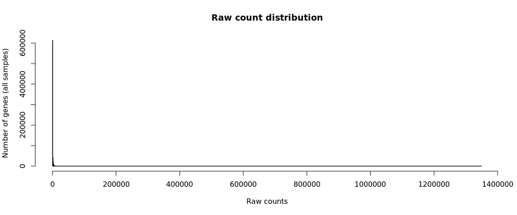

Distribution of raw counts

```r
hist(unlist(rawCounts), breaks = 1000,
     main = "Raw count distribution",
     xlab = "Raw counts",
     ylab = "Number of genes (all samples)")
```

The distribution of raw counts is not very informative, because the range is defined by some outlier, i.e. a gene having a huge number of reads. Even with strong zoom on the abcsissa range from 0 to 500, the histogram shows a steep drop in the first bins.